# Dada2_Pozuelo2015

# Import library

```r
library(dada2)
packageVersion("dada2") # check dada2 version
```

```
## [1] '1.21.0'
```

```r
library(Biostrings)
library(ShortRead)
library(seqTools) # per base sequence content
library(phyloseq)
library(ggplot2)
library(data.table)
library(plyr)
library(dplyr)
library(qckitfastq) # per base sequence content
library(stringr)
```

## QUALITY CHECK

First, we import the fastq files containing the raw reads. The samples were downloaded from the ENA database with the accession number PRJNA268708.

```r
# Save the path to the directory containing the fastq zipped files
path <- "~/Projects/IBS_Meta-analysis_16S/data/analysis-individual/Pozuelo-2015"
# list.files(path) # check we are in the right directory

# fastq filenames have format: SAMPLENAME.fastq.gz
# Saves the whole directory path to each file name
FNs <- sort(list.files(file.path(path, "original"), pattern=".fastq", full.names = TRUE))
show(FNs[1:5])
```

```
## [1] "/Users/scarcy/Projects/IBS_Meta-analysis_16S/data/analysis-individual/Pozuelo-2015/original/SRR1686980.fastq"
## [2] "/Users/scarcy/Projects/IBS_Meta-analysis_16S/data/analysis-individual/Pozuelo-2015/original/SRR1686981.fastq"
## [3] "/Users/scarcy/Projects/IBS_Meta-analysis_16S/data/analysis-individual/Pozuelo-2015/original/SRR1686982.fastq"
## [4] "/Users/scarcy/Projects/IBS_Meta-analysis_16S/data/analysis-individual/Pozuelo-2015/original/SRR1687009.fastq"
## [5] "/Users/scarcy/Projects/IBS_Meta-analysis_16S/data/analysis-individual/Pozuelo-2015/original/SRR1687039.fastq"
```

```r
# Extract sample names, assuming filenames have format: SAMPLENAME.fastq
sample.names <- sapply(strsplit(basename(FNs), "[.]"), `[`, 1)
show(sample.names[1:5]) # saves only the file name (without the path)
```

```
## [1] "SRR1686980" "SRR1686981" "SRR1686982" "SRR1687009" "SRR1687039"
```

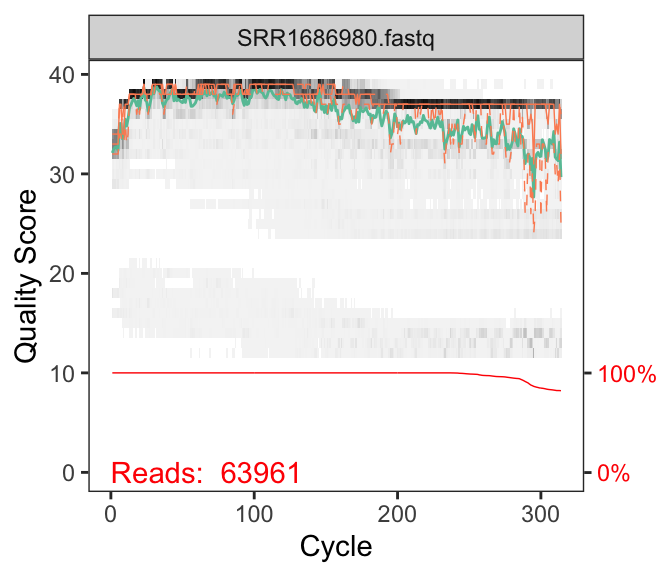

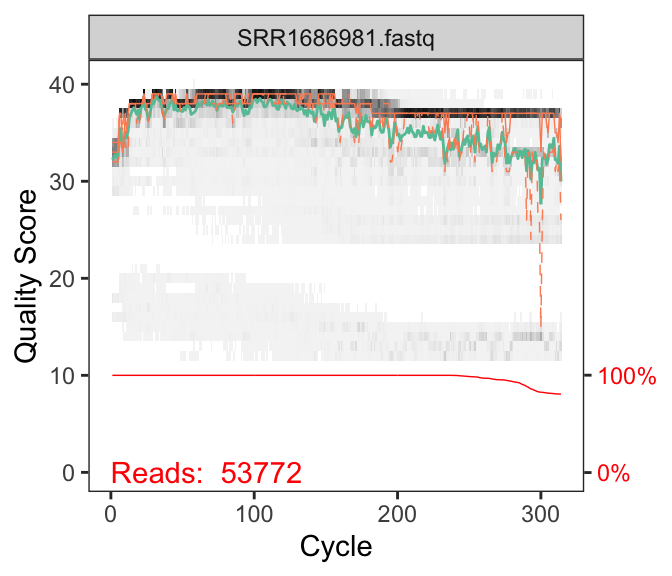

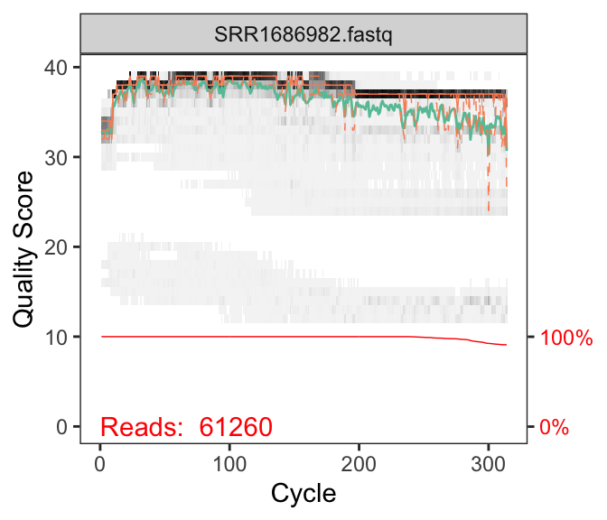

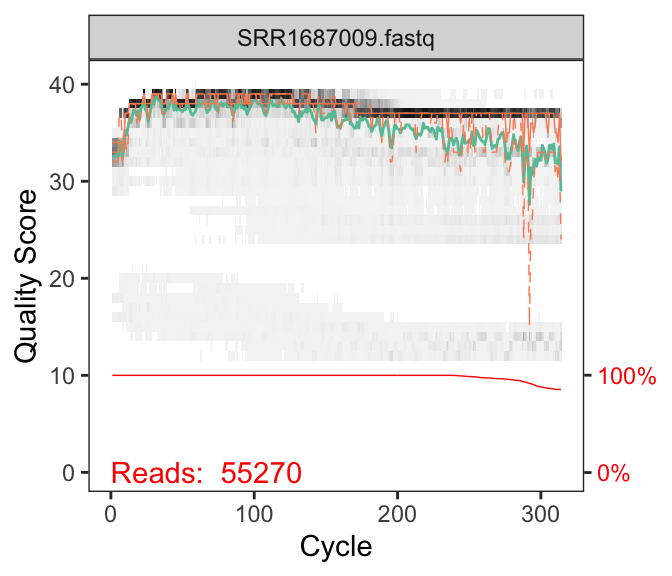

```r
# Look at quality of all files
for (i in 1:4){ # 1:length(FNs)
  show(plotQualityProfile(FNs[i]))
}
```

```r
# Look at nb of reads per sample
# raw_stats <- data.frame('sample' = sample.names,
#                         'reads' = fastqq(FNs)@nReads)
# min(raw_stats$reads)
# max(raw_stats$reads)
# mean(raw_stats$reads)
```

We will have a quick peak at the per base sequence content of the reads in some samples, to make sure there is no anomaly (i.e. all reads having the same sequence).

```r
# Look at per base sequence content
fseq <- seqTools::fastqq(FNs[10])
```

```
## [fastqq] File ( 1/1) '/Users/scarcy/Projects/IBS_Meta-analysis_16S/data/analysis-individual/Pozuelo-2015/original/SRR1687044.fastq'  done.
```

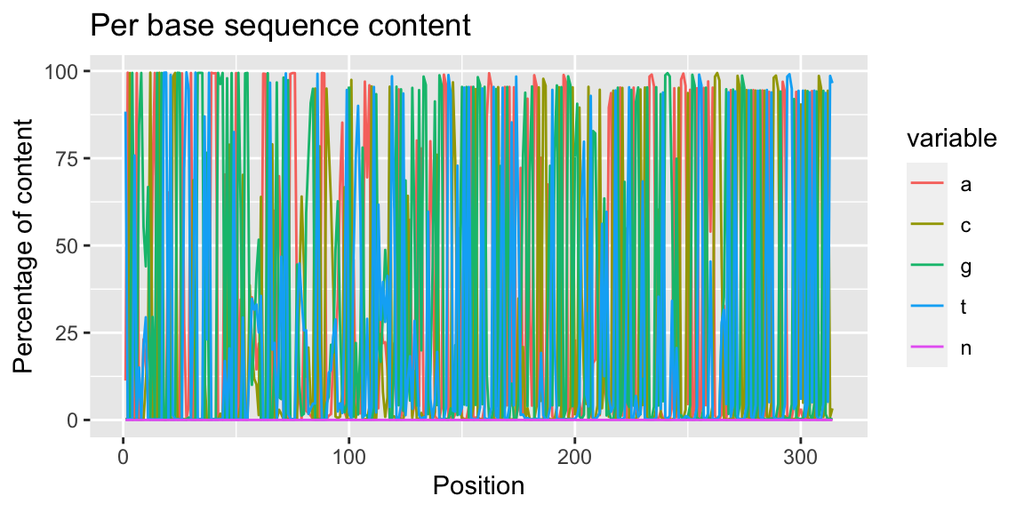

```r
rc <- read_content(fseq)
plot_read_content(rc) + labs(title = "Per base sequence content")
```

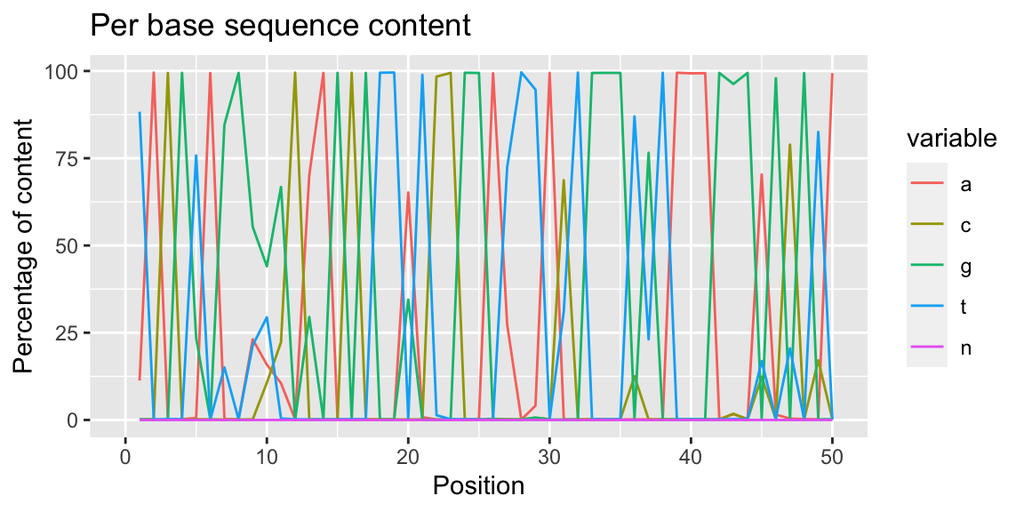

```r
plot_read_content(rc) + xlim(0,50) + labs(title = "Per base sequence content")
```

## LOOK FOR PRIMERS

Now, we will look whether the reads still contain the primers.

```r
# V4
FWD <- "GTGCCAGCMGCCGCGGTAA"  # 515F primer sequence
REV <- "GGACTACHVGGGTWTCTAAT" # 806R primer sequence

# Function that, from the primer sequence, will return all combinations possible (complement, reverse complement, ...)
allOrients <- function(primer) {
    # Create all orientations of the input sequence
    require(Biostrings)
    dna <- DNAString(primer)  # The Biostrings works w/ DNAString objects rather than character vectors
    orients <- c(Forward = dna, Complement = complement(dna), Reverse = reverse(dna),
        RevComp = reverseComplement(dna))
    return(sapply(orients, toString))
}

# Get all combinations of the primer sequences
FWD.orients <- allOrients(FWD) # 515F
REV.orients <- allOrients(REV) # 806R
FWD.orients # sanity check
```

```
##               Forward            Complement               Reverse
## "GTGCCAGCMGCCGCGGTAA" "CACGGTCGKCGGCGCCATT" "AATGGCGCCGMCGACCGTG"
##               RevComp
## "TTACCGCGGCKGCTGGCAC"
```

```r
REV.orients
```

```
##                Forward             Complement                Reverse
## "GGACTACHVGGGTWTCTAAT" "CCTGATGDBCCCAWAGATTA" "TAATCTWTGGGVHCATCAGG"
##                RevComp
## "ATTAGAWACCCBDGTAGTCC"
```

```r
# Function that counts number of reads in which a sequence is found
primerHits <- function(primer, fn) {
    nhits <- vcountPattern(primer, sread(readFastq(fn)), fixed = FALSE, max.mismatch = 2)
    return(sum(nhits > 0))
}

# Get a table to know how many times the 515F and 806R primers are found in the reads of each sample
for (i in 1:5){
  cat("SAMPLE", sample.names[i], "with total number of", raw_stats[i,'reads'], "reads\n\n")
  x <-  rbind(ForwardPrimer = sapply(FWD.orients, primerHits, fn = FNs[[i]]),
              ReversePrimer = sapply(REV.orients, primerHits, fn = FNs[[i]]))
  print(x)
  cat("\n____________________________________________\n\n")
}
```

```
## SAMPLE SRR1686980 with total number of 63961 reads
##
##               Forward Complement Reverse RevComp
## ForwardPrimer       0          0       0       0
## ReversePrimer       0          0       0   60602
##
## ____________________________________________
##
## SAMPLE SRR1686981 with total number of 53772 reads
##
##               Forward Complement Reverse RevComp
## ForwardPrimer       0          0       0       0
## ReversePrimer       0          0       0   50449
##
## ____________________________________________
##
## SAMPLE SRR1686982 with total number of 61260 reads
##
##               Forward Complement Reverse RevComp
## ForwardPrimer       0          0       0       0
## ReversePrimer       0          0       0   59080
##
## ____________________________________________
##
## SAMPLE SRR1687009 with total number of 55270 reads
##
##               Forward Complement Reverse RevComp
## ForwardPrimer       0          0       0       0
## ReversePrimer       0          0       0   52588
##
## ____________________________________________
##
## SAMPLE SRR1687039 with total number of 62765 reads
##
##               Forward Complement Reverse RevComp
## ForwardPrimer       0          0       0       0
## ReversePrimer       0          0       0   59425
##
## ____________________________________________
```

## FILTER AND TRIM

### 1. Primer removal

The reads indeed contain the reverse primer. The reverse complement of the reverse primer is found at the **end** of the reads, which is expected. We could not find the forward primer, but we need to give a *primer.fwd* parameter to the function ‘removePrimers’… We will reverse complement the reads, so that the reverse primer can be set as a *primer.fwd* in the function. Then we will reverse-complement the filtered reads again, so they are kept in their original orientation.

```r
# REVERSE COMPLEMENT THE READS
FNs_revcomp <- file.path(path, "original(revcomp)", paste0(sample.names, "_revcomp.fastq.gz"))
names(FNs_revcomp) <- sample.names

# Write reverse complement of the reads
for (i in 1:length(FNs)){
  fq <- reverseComplement(readFastq(FNs[i]))
  fout <- FNs_revcomp[i]
  writeFastq(fq, fout)
}


# KEEP READS WITH PRIMER AND REMOVE PRIMER
# Place filtered files in a filtered/ subdirectory
filt1_revcomp <- file.path(path, "filtered1(revcomp)", paste0(sample.names, "_filt_revcomp.fastq.gz"))
# Assign names for the filtered fastq.gz files
names(filt1_revcomp) <- sample.names

out1 <- removePrimers(fn = FNs_revcomp, fout = filt1_revcomp,
                      primer.fwd = REV.orients['Forward'], # reverse primer found at the beginning of all reads
                      trim.fwd = TRUE,
                      orient = FALSE, # keep the reads in their original orientation
                      compress = TRUE, verbose = TRUE)


# REVERSE COMPLEMENT THE FILTERED READS
filt1_samples <- file.path(path, "filtered1", paste0(sample.names, "_filt1.fastq.gz"))
names(filt1_samples) <- sample.names

# Write reverse complement of the reads
for (i in 1:length(filt1_revcomp)){
  fq <- reverseComplement(readFastq(filt1_revcomp[i]))
  fout <- filt1_samples[i]
  writeFastq(fq, fout)
}
```

```r
# Primer removal
rownames(out1) <- sample.names
out1[1:5,]
```

```
##            reads.in reads.out
## SRR1686980    63961     60602
## SRR1686981    53772     50449
## SRR1686982    61260     59080
## SRR1687009    55270     52588
## SRR1687039    62765     59425
```

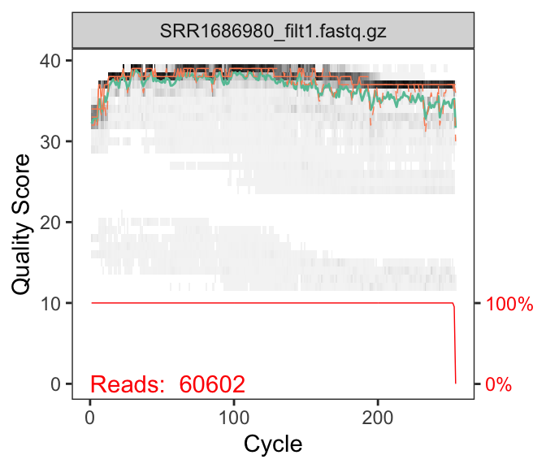

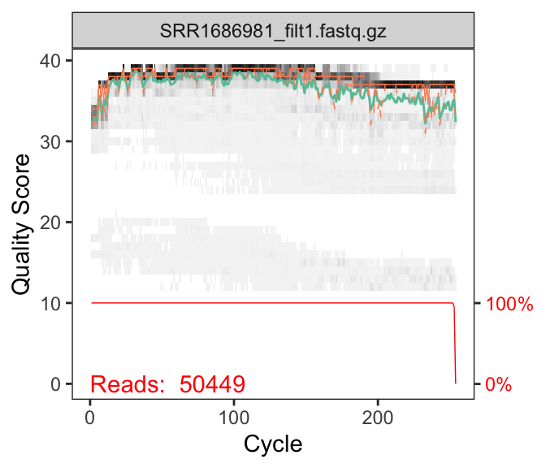

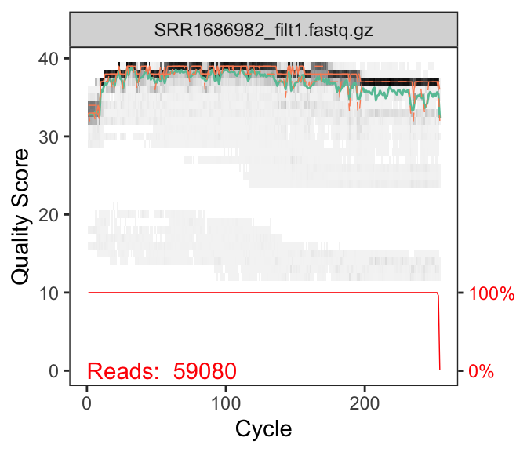

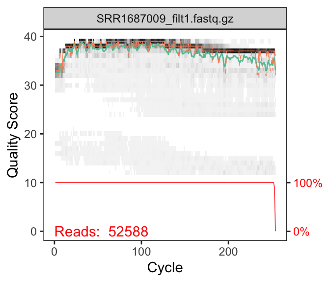

```r
# Quality profile after primer removal
for (i in 1:4){
  show(plotQualityProfile(filt1_samples[i]))
}
```

We can see that the reads length has quite reduced (from ~300bp to ~250bp). Looking at the fastq files, the reverse primer was not at the very end of the reads, it was followed by the Golay barcode and other specific sequences described in the methods of the article (we can notably recognize the reverse complement of the full specific sequences 5’-{CAAGCAGAAGACGGCATACGAGAT} {Golay barcode} {AGTCAGTCAGCC} {reverse primer}-3’).

### 2. Quality filtering

Then, we perform a quality filtering of the reads.

```r
# Place filtered files in a filtered/ subdirectory
filt2_samples <- file.path(path, "filtered2", paste0(sample.names, "_filt2.fastq.gz"))
# Assign names for the filtered fastq.gz files
names(filt2_samples) <- sample.names

out2 <- filterAndTrim(fwd = filt1_samples, filt = filt2_samples,
                      maxEE=3, # reads with more than 3 expected errors (sum(10e(-Q/10))) are discarded
                      truncQ=10, # Truncate reads at the first instance of a quality score less than or equal to truncQ.
                      minLen=150, # Discard reads shorter than 150 bp. This is done after trimming and truncation.
                      compress=TRUE, multithread=TRUE, verbose=TRUE)
```

Let’s look at the output filtered fastq files as sanity check.

```r
out2[1:4,] # show how many reads were filtered in each file
```

```
##                           reads.in reads.out
## SRR1686980_filt1.fastq.gz    60602     60576
## SRR1686981_filt1.fastq.gz    50449     50435
## SRR1686982_filt1.fastq.gz    59080     59059
## SRR1687009_filt1.fastq.gz    52588     52560
```

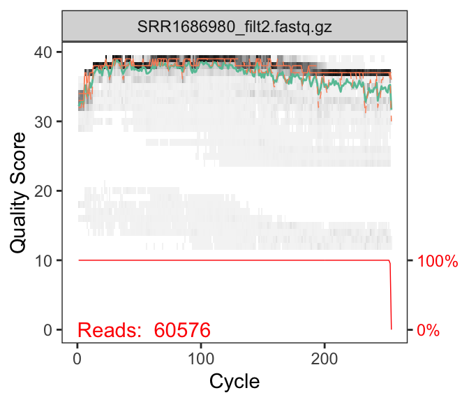

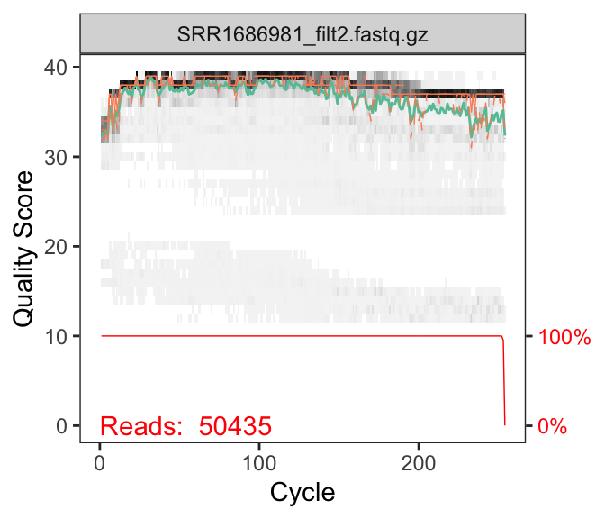

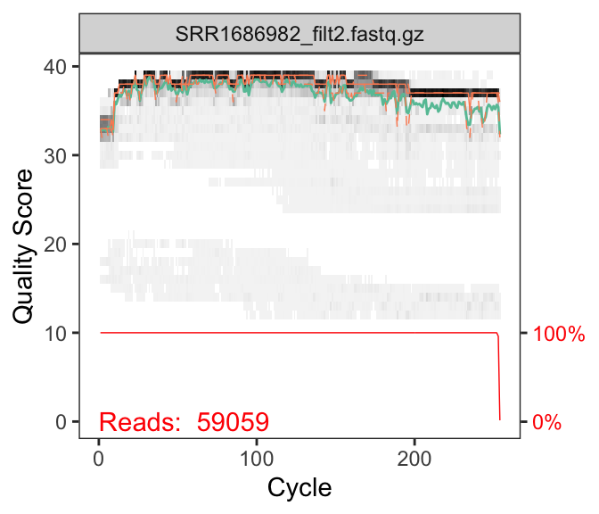

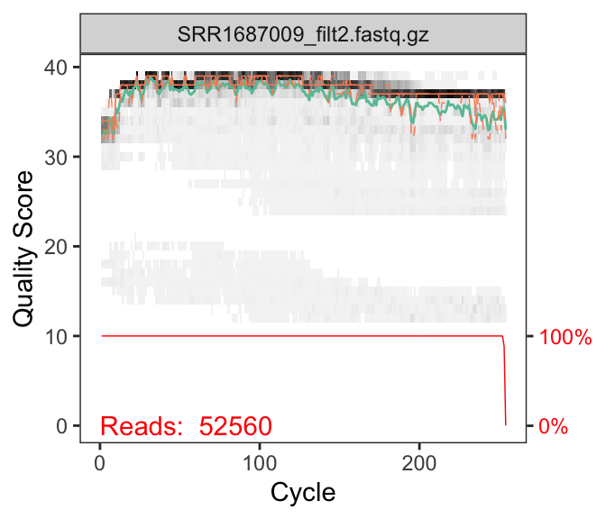

```r
# Look at quality profile of filtered files
for (i in 1:4){
  show(plotQualityProfile(filt2_samples[i]))
}
```

## LEARN ERROR RATES

Now we will build the parametric error model, to be able to infer amplicon sequence variants (ASVs) later on.

```r
err <- learnErrors(filt2_samples, multithread=TRUE, randomize=TRUE, verbose = 1)
```

The error rates for each possible transition (A→C, A→G, …) are shown. Points are the observed error rates for each consensus quality score. The black line shows the estimated error rates after convergence of the machine-learning algorithm. The red line shows the error rates expected under the nominal definition of the Q-score. Here the estimated error rates (black line) are a good fit to the observed rates (points), and the error rates drop with increased quality as expected.

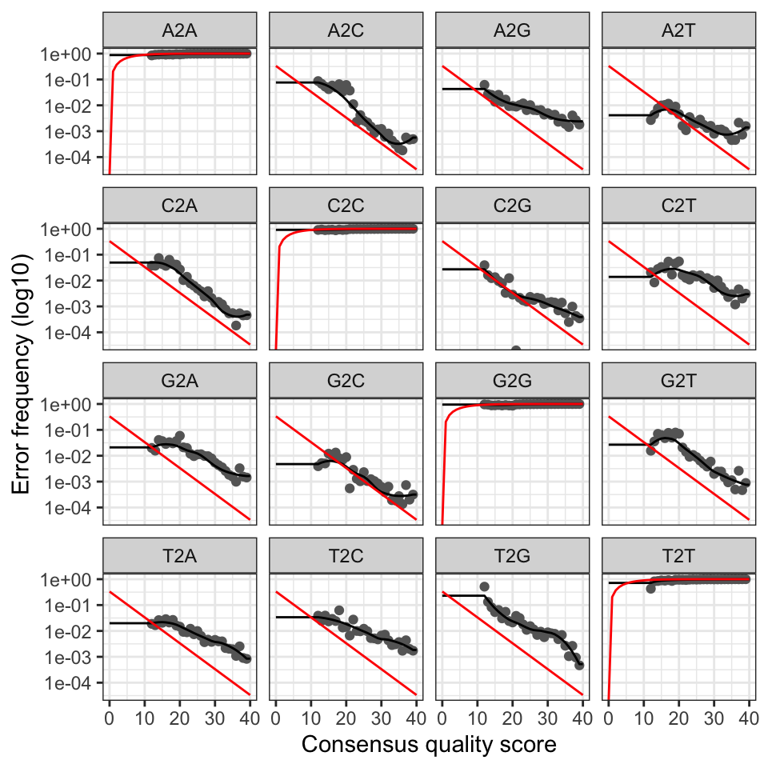

```r
plotErrors(err, nominalQ = TRUE)
```

## CONSTRUCT SEQUENCE TABLE

### 1. Infer sample composition

The *dada()* algorithm infers sequence variants based on estimated errors (previous step). Firstly, we de-replicate the reads in each sample, to reduce the computation time. De-replication is a common step in almost all modern ASV inference (or OTU picking) pipelines, but a unique feature of derepFastq is that it maintains a summary of the quality information for each dereplicated sequence in $quals.

```r
# Prepare empty vector for the infered sequences
seq_infered <- vector("list", length(sample.names))
names(seq_infered) <- sample.names

# Iterate through the 290 samples
for(sampl in sample.names) {
  cat("Processing:", sampl, "\n")
  derep <- derepFastq(filt2_samples[[sampl]]) # dereplicate the reads in the sample
  seq_infered[[sampl]] <- dada(derep, err=err, multithread=TRUE) # default parameters
}
```

```r
# Inspect the infered sequence variants from sample 1:3
for (i in 1:3){
  print(seq_infered[[i]])
  print("________________")
}
```

```
## dada-class: object describing DADA2 denoising results
## 543 sequence variants were inferred from 17303 input unique sequences.
## Key parameters: OMEGA_A = 1e-40, OMEGA_C = 1e-40, BAND_SIZE = 16
## [1] "________________"
## dada-class: object describing DADA2 denoising results
## 585 sequence variants were inferred from 16881 input unique sequences.
## Key parameters: OMEGA_A = 1e-40, OMEGA_C = 1e-40, BAND_SIZE = 16
## [1] "________________"
## dada-class: object describing DADA2 denoising results
## 261 sequence variants were inferred from 10307 input unique sequences.
## Key parameters: OMEGA_A = 1e-40, OMEGA_C = 1e-40, BAND_SIZE = 16
## [1] "________________"
```

### 2. Construct ASV table

We can now construct an amplicon sequence variant table (ASV) table, a higher-resolution version of the OTU table produced by traditional methods.

```r
# Make sequence table from the infered sequence variants
seqtable <- makeSequenceTable(seq_infered)

# We should have 290 samples (290 rows)
dim(seqtable)
```

```
## [1]   290 57884
```

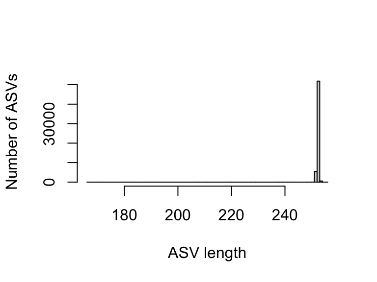

```r
# Inspect distribution of sequence lengths
hist(nchar(getSequences(seqtable)), breaks = 100, xlab = "ASV length", ylab = "Number of ASVs", main="")
```

```r
# Sequences should be between 515F - 806R, so around ~250bp (removing the primers lengths).
# Remove any sequence variant outside 200:300bp
seqtable.new <- seqtable[,nchar(colnames(seqtable)) %in% 200:300]
dim(seqtable.new)
```

```
## [1]   290 57879
```

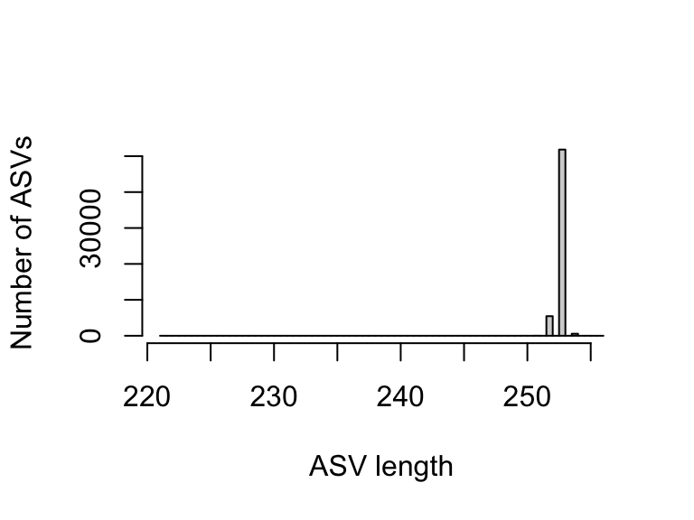

```r
hist(nchar(getSequences(seqtable.new)), breaks = 100, xlab = "ASV length", ylab = "Number of ASVs", main="")
```

### 3. Remove chimeras

The core dada method corrects substitution and indel errors, but chimeras remain. Fortunately, the accuracy of sequence variants after denoising makes identifying chimeric ASVs simpler than when dealing with fuzzy OTUs. Chimeric sequences are identified if they can be exactly reconstructed by combining a left-segment and a right-segment from two more abundant “parent” sequences.

```r
seqtable.nochim <- removeBimeraDenovo(seqtable.new, method="consensus", multithread=TRUE, verbose=TRUE)

# Check how many sequence variants we have after removing chimeras
dim(seqtable.nochim)
```

```
## [1]   290 23849
```

```r
# Check how many reads we have after removing chimeras (we should keep the vast majority of the reads, like > 80%)
sum(seqtable.nochim)/sum(seqtable.new)
```

```
## [1] 0.7743955
```

## LOOK AT READS COUNT THROUGH PIPELINE

Sanity check before assigning taxonomy.

```r
# Function that counts nb of reads
getN <- function(x) sum(getUniques(x))

# Table that will count number of reads for each process of interest (input reads, filtered reads, denoised reads, non chimera reads)
track <- cbind(out1,
               out2[,2],
               sapply(seq_infered, getN),
               rowSums(seqtable.nochim),
               lapply(rowSums(seqtable.nochim)*100/out1[,1], as.integer))

# Assign column and row names
colnames(track) <- c("input", "primer-filt", "quality-filt", "denoised", "nonchim", "%input->output")

# Show final table: for each row/sample, we have shown the initial number of reads, filtered reads, denoised reads, and non chimera reads
track
```

```
##            input primer-filt quality-filt denoised nonchim %input->output
## SRR1686980 63961 60602       60576        59085    41910   65
## SRR1686981 53772 50449       50435        48446    35531   66
## SRR1686982 61260 59080       59059        58381    42050   68
## SRR1687009 55270 52588       52560        50859    41082   74
## SRR1687039 62765 59425       59419        57900    40693   64
## SRR1687040 53976 51637       51618        49556    39130   72
## SRR1687041 48624 45911       45895        44482    35164   72
## SRR1687042 45692 43529       43511        41889    36157   79
## SRR1687043 47935 45526       45512        43672    31589   65
## SRR1687044 40831 38595       38586        36312    25775   63
## SRR1687045 57852 55329       55321        53536    36596   63
## SRR1687047 68611 66375       66360        65015    55275   80
## SRR1687049 54225 51125       51109        49370    33555   61
## SRR1687050 49961 47323       47304        45467    34163   68
## SRR1687052 49243 46849       46822        44504    36198   73
## SRR1687055 58048 55814       55794        54039    44439   76
## SRR1687056 59818 56702       56683        55441    39186   65
## SRR1687058 61999 59480       59461        57614    44854   72
## SRR1687059 69071 66588       66574        65896    56106   81
## SRR1687061 67721 63936       63915        63344    44786   66
## SRR1687062 47867 45591       45581        43677    31182   65
## SRR1687063 56572 53079       53072        51485    34465   60
## SRR1687064 65666 62261       62248        60203    38973   59
## SRR1687065 43232 41192       41177        40243    27042   62
## SRR1687066 61352 58866       58844        57164    42806   69
## SRR1687067 63226 60516       60500        58007    42333   66
## SRR1687068 70848 67731       67711        65340    43951   62
## SRR1687069 77649 74927       74901        73838    66771   85
## SRR1687094 65202 62497       62485        60841    42787   65
## SRR1687095 46172 44625       44610        43748    37677   81
## SRR1687096 73988 70731       70709        69189    49753   67
## SRR1687097 60556 56916       56882        54076    38999   64
## SRR1687098 67096 63590       63571        61259    40813   60
## SRR1687100 69866 66667       66639        64426    48908   70
## SRR1687171 77698 75057       75023        73649    60209   77
## SRR1687172 69722 65137       65130        64533    40611   58
## SRR1687173 40816 38566       38557        37393    29511   72
## SRR1687174 77073 74513       74486        73720    57708   74
## SRR1687425 65762 62457       62444        60006    44417   67
```

[output cut: 236 more lines]

```
## SRR1766080 53215 46881       46867        44415    35045   65
## SRR1766081 48781 42988       42973        41321    29102   59
## SRR1766082 45900 40428       40411        38906    28023   61
## SRR1766083 44434 39423       39400        37510    31963   71
## SRR1766084 55284 49007       48993        47446    34813   62
## SRR1766085 40086 34458       34447        32936    25947   64
## SRR1766086 49126 44445       44425        42548    34584   70
## SRR1766087 53969 47683       47661        45181    35714   66
## SRR1766088 55351 48415       48405        46182    36031   65
## SRR1766089 50686 43982       43968        42400    34931   68
## SRR1766090 52656 47313       47295        45405    38340   72
## SRR1766091 48458 43049       43024        41244    35541   73
## SRR1766092 50835 44834       44826        42801    32208   63
## SRR1766093 47741 41888       41879        40296    29473   61
## SRR1766094 42609 37329       37320        35986    28313   66
```

## ASSIGN TAXONOMY

```r
# Assign taxonomy (with silva v138)
taxa <- assignTaxonomy(seqtable.nochim, "~/Projects/IBS_Meta-analysis_16S/data/silva_nr_v138_train_set.fa.gz",
                       tryRC = TRUE, # try reverse complement of the sequences
                       multithread=TRUE, verbose = TRUE)

# Add species assignment
taxa <- addSpecies(taxa, "~/Projects/IBS_Meta-analysis_16S/data/silva_species_assignment_v138.fa.gz")
```

```r
# Check how the taxonomy table looks like
taxa.print <- taxa
rownames(taxa.print) <- NULL # Removing sequence rownames for display only
head(taxa.print)
```

```
##      Kingdom    Phylum         Class         Order
## [1,] "Bacteria" "Bacteroidota" "Bacteroidia" "Bacteroidales"
## [2,] "Bacteria" "Bacteroidota" "Bacteroidia" "Bacteroidales"
## [3,] "Bacteria" "Firmicutes"   "Clostridia"  "Lachnospirales"
## [4,] "Bacteria" "Bacteroidota" "Bacteroidia" "Bacteroidales"
## [5,] "Bacteria" "Bacteroidota" "Bacteroidia" "Bacteroidales"
## [6,] "Bacteria" "Firmicutes"   "Clostridia"  "Oscillospirales"
##      Family            Genus              Species
## [1,] "Prevotellaceae"  "Prevotella"       "copri"
## [2,] "Bacteroidaceae"  "Bacteroides"      "vulgatus"
## [3,] "Lachnospiraceae" "Blautia"          NA
## [4,] "Bacteroidaceae"  "Bacteroides"      NA
## [5,] "Prevotellaceae"  "Prevotella"       NA
## [6,] "Ruminococcaceae" "Faecalibacterium" NA
```

```r
table(taxa.print[,1]) # Show the different kingdoms
```

[output not shown]

```r
taxa.print[taxa.print[,1] == 'Eukaryota',2] # the eukaryota are either Euglenozoa, or unknown
```

```
##  [1] "Euglenozoa" NA           NA           NA           NA
##  [6] NA           "Euglenozoa" NA           NA           NA
## [11] "Euglenozoa" NA           NA           "Euglenozoa" NA
## [16] "Euglenozoa" NA           NA           NA           NA
## [21] NA           "Euglenozoa" NA           NA           NA
## [26] NA           NA           NA           "Euglenozoa" NA
## [31] NA           NA           "Euglenozoa" NA           NA
## [36] NA           NA           "Euglenozoa" NA           NA
## [41] "Euglenozoa" NA           NA           "Euglenozoa" "Euglenozoa"
## [46] NA           NA           NA           "Euglenozoa" "Euglenozoa"
## [51] NA           NA           NA           NA           "Euglenozoa"
## [56] "Euglenozoa" NA           "Euglenozoa" NA           NA
## [61] "Euglenozoa" NA           NA           "Euglenozoa" NA
## [66] NA           NA           NA           NA           NA
## [71] "Euglenozoa" NA           NA           NA           NA
## [76] NA
```

```r
table(taxa.print[,2]) # Show the different phyla
```

```
##
##  Actinobacteriota      Bacteroidota  Bdellovibrionota  Campilobacterota
##               299              3596                 1                12
##     Cyanobacteria  Desulfobacterota   Elusimicrobiota        Euglenozoa
##                78               125                 6                20
##     Euryarchaeota        Firmicutes    Fusobacteriota    Proteobacteria
##                14             18506                41               425
##     Spirochaetota      Synergistota  Thermoplasmatota Verrucomicrobiota
##                 1                27                 7               119
```

```r
table(is.na(taxa.print[,2])) # is there any NA phyla?
```

```
##
## FALSE  TRUE
## 23277   572
```

## LAST PREPROCESSING

### 1. Create phyloseq object

The preprocessing will be easier to do with ASV, taxonomic and metadata tables combined in a phyloseq object.

```r
#_________________________
# Import metadata
metadata_table <- read.table("~/Projects/IBS_Meta-analysis_16S/data/analysis-individual/Pozuelo-2015/PozueloSraRunTable.txt", header = TRUE, sep = ",")

# Keep relevant covariates
sampledf <- metadata_table[, c("Run", "Sample.Name", "Collection_Date")]
rownames(sampledf) <- sampledf$Run

sampledf$Sample.Name <- as.character(sampledf$Sample.Name)

# Simplify data
sampledf$Collection <- "1st" # add column to specify if sample is from first or 2nd collection
sampledf[gsub('.*(?=.{2}$)', '', sampledf$Sample.Name, perl=T) == '.2', 'Collection'] <- "2nd"

sampledf$host_disease <- "Healthy" # add column for host_disease
sampledf[substr(sampledf$Sample.Name, 1, 2) == "MO", 'host_disease'] <- "IBS"
sampledf[, 'Sample.Name'] <- gsub("MO", "IBS", sampledf[, 'Sample.Name']) # replace 'MO' by 'IBS' in the sample.names
sampledf$Sample.Name <- gsub("\\.2$", "", sampledf[, 'Sample.Name']) # remove the '.2' at the end of some of the sample.names (indicating it is the 2nd collection)

colnames(sampledf) <- c("Run", "host_ID", "collection_date", "Collection", "host_disease")

sampledf$sample_type <- "stool"
sampledf$author <- "Pozuelo"
sampledf$sequencing_tech <- "Illumina"
sampledf$variable_region <- "V4"

# Remove .fastq extension in seqtable.nochim
# rownames(seqtable.nochim) <- gsub(".fastq", "", rownames(seqtable.nochim))

#_________________________
# Create phyloseq object
physeq <- phyloseq(otu_table(seqtable.nochim, taxa_are_rows=FALSE), # by default, in otu_table the sequence variants are in rows
                   sample_data(sampledf),
                   tax_table(taxa))

# Remove taxa that are eukaryota, or have unassigned Phyla
physeq <- subset_taxa(physeq, Kingdom != "Eukaryota")
physeq <- subset_taxa(physeq, !is.na(Phylum))
```

### 2. Save to disk

```r
# Save to disk
saveRDS(raw_stats, file.path(path, "01_Dada2-Pozuelo/raw_stats.rds"))
saveRDS(out1, file.path(path, "01_Dada2-Pozuelo/out1.rds"))
saveRDS(out2, file.path(path, "01_Dada2-Pozuelo/out2.rds"))
saveRDS(err, file.path(path, "01_Dada2-Pozuelo/err.rds"))
saveRDS(seq_infered, file.path(path, "01_Dada2-Pozuelo/seq_infered.rds"))

saveRDS(otu_table(physeq), file.path(path, "01_Dada2-Pozuelo/ASVtable_final.rds")) # ASV table
saveRDS(tax_table(physeq), file.path(path, "01_Dada2-Pozuelo/taxa_final.rds")) # taxa table
saveRDS(sample_data(physeq), file.path(path, "01_Dada2-Pozuelo/metadata_final.rds")) # metadata table

# Taxa & Phyloseq object
saveRDS(taxa, "~/Projects/IBS_Meta-analysis_16S/data/analysis-individual/CLUSTER/Taxonomy/output/taxa_pozuelo.rds")
saveRDS(physeq, "~/Projects/IBS_Meta-analysis_16S/data/analysis-individual/CLUSTER/PhyloTree/input/physeq_pozuelo.rds")
```

### 3. Quick peek at data analysis

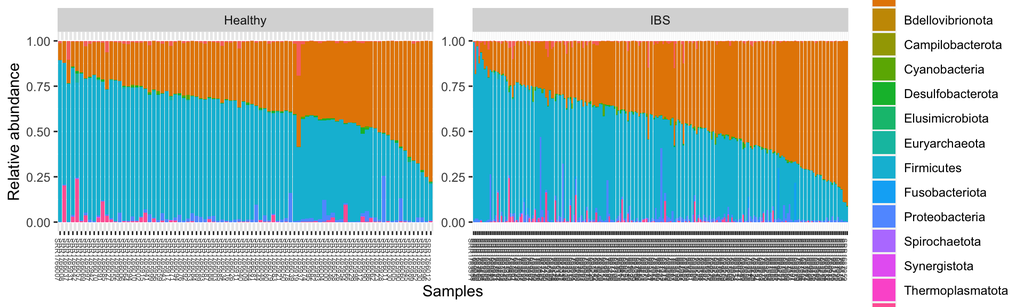

```r
# Absolute abundance
# plot_bar(physeq, fill = "Phylum")+ facet_wrap("host_disease", scales="free_x") + theme(axis.text.x = element_blank())

# Relative abundance for Phylum
phylum.table <- physeq %>%
  tax_glom(taxrank = "Phylum") %>%                     # agglomerate at phylum level
  transform_sample_counts(function(x) {x/sum(x)} ) %>% # Transform to rel. abundance
  psmelt()                                             # Melt to long format

ggplot(phylum.table, aes(x = reorder(Sample, Sample, function(x) mean(phylum.table[Sample == x & Phylum == 'Bacteroidota', 'Abundance'])),
                         y = Abundance, fill = Phylum))+
  facet_wrap(~ host_disease, scales = "free") + # scales = "free" removes empty lines
  geom_bar(stat = "identity") +
  theme(axis.text.x = element_text(size = 5, angle = -90))+
  labs(x = "Samples", y = "Relative abundance")
```